# Hybrid Query Selection Workflow for Bayesian Optimization

This notebook demonstrates a **hybrid strategy** for selecting query points in a Bayesian Optimization setting.  
The approach combines:

- **Acquisition functions** (Expected Improvement and Upper Confidence Bound) for systematic exploration/exploitation.
- **Targeted perturbations** around top-performing points for flexibility and faster convergence.

### Why Hybrid?

- Pure exploration can miss subtle nonlinear interactions.
- Pure exploitation risks premature convergence.
- A hybrid approach accelerates learning while maintaining diversity.

### Directions for Use:

1. **Run the setup cells** to load functions for GP fitting, acquisition functions, perturbations, and visualisations.
2. **Provide your observed data** (`X`, `Y`) from previous rounds.
3. **Fit the GP model** and compute acquisition scores.
4. **Generate candidate queries** using the hybrid strategy.
5. **Visualise results** to guide your next round of submissions.

```python
import numpy as np
import matplotlib.pyplot as plt
from sklearn.gaussian_process import GaussianProcessRegressor
#from sklearn.gaussian_process.kernels import RBF
from sklearn.gaussian_process.kernels import Matern, WhiteKernel, ConstantKernel
from scipy.stats import norm
import pandas as pd
from pandas.plotting import parallel_coordinates
from typing import Optional, Tuple, List
from sklearn.preprocessing import StandardScaler
from sklearn.exceptions import ConvergenceWarning
from scipy.stats import norm
import warnings

# Suppress only ConvergenceWarning from sklearn (safe and targeted)
warnings.filterwarnings("ignore", category=ConvergenceWarning)
```

## Step 1: Fit a Gaussian Process Surrogate Model

We use a GP with an Matern kernel to model the unknown function based on observed data.

```python
def fit_gp(
    X: np.ndarray,
    Y: np.ndarray,
    *,
    random_state: int = 0,
    # GP fitting knobs (auto-scaled if None)
    n_restarts: Optional[int] = None,
    nu: float = 2.5,
    standardize_y: bool = True,
    suppress_convergence_warnings: bool = False,
    length_scale_lower: Optional[float] = None,
    length_scale_upper: Optional[float] = None,
    noise_lower: Optional[float] = None,
    noise_upper: Optional[float] = None,
    # Proposal knobs (auto-scaled by dimension if None)
    proposal_k_final: int = 5,
    proposal_random_state: Optional[int] = None,
    proposal_n_global: Optional[int] = None,
    proposal_n_trust: Optional[int] = None,
    proposal_trust_radius: Optional[float] = None,
    proposal_kappa: float = 2.0,
) -> Tuple[GaussianProcessRegressor, Tuple[List[np.ndarray], List[str]]]:
    """Fit an ARD Matern+White GP with dimension/data-aware bounds and propose queries.
    Returns: gp, (numeric_candidates, formatted_candidates)
    """

    # --- 0) Dimension-aware config ---
    if suppress_convergence_warnings:
        warnings.filterwarnings("ignore", category=ConvergenceWarning)

    if X.ndim == 1:
        X = X.reshape(-1, 1)
    n, D = int(X.shape[0]), int(X.shape[1])

    # Restarts: scale by D and n, cap at 60
    if n_restarts is None:
        import math
        n_restarts = int(20 + 5 * min(D, 8) + 5 * math.log10(max(n, 10)))
        n_restarts = min(max(n_restarts, 20), 60)

    # Y standardization & normalize_y flag
    if standardize_y:
        scaler = StandardScaler(with_mean=True, with_std=True)
        Y_fit = scaler.fit_transform(Y.reshape(-1, 1)).ravel()
        normalize_y = False
    else:
        Y_fit = Y
        normalize_y = True


    # Per-dimension spread and geometric mean (more robust in heterogeneous D)
    s_per_dim = np.std(X, axis=0) + 1e-12
    gm_s = float(np.exp(np.mean(np.log(s_per_dim))))


    # If caller provides explicit bounds, keep them; else compute
    if length_scale_lower is None:
        # Lower bound shrinks with sqrt(D) to keep local sensitivity in higher-D
        length_scale_lower = max(1e-3, 0.25 * gm_s / max(np.sqrt(D), 1.0))

    if length_scale_upper is None:
        # Upper bound grows with sqrt(D) to allow smoother functions in higher-D
        # Use a generous starting cap; we will widen adaptively if we still peg.
        length_scale_upper = min(30.0, 6.0 * gm_s * max(np.sqrt(D), 1.0))


    # Noise bounds: tighter for standardized Y
    if noise_lower is None:
        noise_lower = 1e-12 if standardize_y else 1e-14
    if noise_upper is None:
        noise_upper = 0.75 if standardize_y else max(1e-3, 0.5 * float(np.std(Y)))

#=====
    # Proposal defaults by dimension
    if proposal_random_state is None:
        proposal_random_state = random_state
    if proposal_n_global is None:
        proposal_n_global = 2000 * min(D, 8)
    if proposal_n_trust is None:
        proposal_n_trust = 16 + 8 * min(D, 8)
    if proposal_trust_radius is None:
        proposal_trust_radius = 0.03 / max(np.sqrt(D), 1.0)

    # --- 2) Kernel builder (ARD Matern + White) ---

    # Heuristic ARD init: start each dimension at its own spread# Heuristic ARD init: start each dimension at
    c_init = 1.0                # neutral; tune to 0.5–1.5 if needed
    ls0 = c_init * (np.std(X, axis=0) + 1e-12)

    def _make_kernel(ls_up: float, ls_init: np.ndarray):
        amp_bounds = (1e-6, 1e3) if standardize_y else (1e-6, 1e4)
        return (
            ConstantKernel(1.0, amp_bounds)
            * Matern(length_scale=ls_init,
                     length_scale_bounds=(length_scale_lower, ls_up),
                     nu=nu)
                   + WhiteKernel(noise_level=1e-4,
                          noise_level_bounds=(noise_lower, noise_upper),))


    # --- 3) Fit with bounded retry (at most 1 widening, capped upper bound) ---
    gp = None
    ls_up = float(length_scale_upper)
    tries, max_tries = 0, 6
    while tries <= max_tries:
        kernel = _make_kernel(ls_up,ls0)
        gp = GaussianProcessRegressor(
            kernel=kernel,
            normalize_y=normalize_y,
            n_restarts_optimizer=max(n_restarts,30), #ensure at least 30 restarts
            random_state=random_state,
        )
        gp.fit(X, Y_fit)


        # Inspect learned params and see if we hit upper bounds
        need_retry = False
        ls_hit_upper = False  # local helper to decide if we should smooth ls


        try:
            # Kernel layout: Constant * (Matern + White)
            matern = gp.kernel_.k1.k2
            white = gp.kernel_.k2


            # Length-scale upper bound peg check (ARD vector)
            ls_learned     = np.asarray(matern.length_scale, dtype=float)
            ls_upper_bound = float(matern.length_scale_bounds[1])
            ls_hit_upper   = np.any(ls_learned >= 0.985 * ls_upper_bound)

            # Noise upper/lower bound checks
            noise_learned     = float(white.noise_level)
            noise_lower_bound = float(white.noise_level_bounds[0])
            noise_upper_bound = float(white.noise_level_bounds[1])

            # Retry if either upper bound is effectively hit
            need_retry = ls_hit_upper or (noise_learned >= 0.985 * noise_upper_bound)

            # If noise hugs the lower bound, relax it further next time (avoid fake smoothness)
            if noise_learned <= 1.02 * noise_lower_bound:
                noise_lower = max(1e-14, noise_lower * 0.1)

            # If noise hugs the upper bound, lift the cap (preserving your variable)
            if noise_learned >= 0.985 * noise_upper_b:
                noise_upper = min(
                    (noise_upper if noise_upper is not None else noise_upper_bound) * 2.0,
                    2.0 if standardize_y else max(1.0, 10.0 * float(np.std(Y)))
                )

        except Exception:
            # If we cannot read kernel internals, assume no retry is needed
            need_retry = False
            ls_hit_upper = False

           # Exit when a retry is not needed (good fit achieved)
        if not need_retry:
            break


        # Prepare next try: widen and smooth, dimension-aware using your 'D
        tries += 1
         # Widen factor stronger than 3×; ceiling grows with sqrt(D)
        ls_up = min(ls_up * 5.0, 1500.0* max(np.sqrt(D), 1.0))  # D-aware cap

        # If length-scale pegged, start closer to the smoother regime
        if ls_hit_upper:
                ls0 = np.clip(ls0 * 2.0, length_scale_lower, ls_up)

        # Increase restarts modestly as we retry (uses your n_restart
        n_restarts = max(n_restarts + 8, 100)


    # --- 4) Proposal step (EI + UCB + trust-region) ---
    rng = np.random.default_rng(proposal_random_state)

    def _lhs(n_samples: int, d: int, rng_):
        cut = np.linspace(0, 1, n_samples + 1)
        a, b = cut[:-1], cut[1:]
        Xg = rng_.uniform(a, b, size=(d, n_samples)).T
        for j in range(d):
            rng_.shuffle(Xg[:, j])
        return Xg


    Xg = _lhs(proposal_n_global, D, rng)
    Y_best_val = float(np.max(Y_fit))
    X_best = X[int(np.argmax(Y_fit))]
    deltas = rng.uniform(-proposal_trust_radius, proposal_trust_radius, size=(proposal_n_trust, D))
    Xt = np.clip(X_best + deltas, 0.0, 1.0 - 1e-6)

    Xc = np.vstack([Xg, Xt])

    mean, std = gp.predict(Xc, return_std=True)
    std = np.maximum(std, 1e-9)
    xi = 0.01
    imp = mean - Y_best_val - xi
    Z = imp / std
    ei = imp * norm.cdf(Z) + std * norm.pdf(Z)
    tight = std <= 1e-9
    if np.any(tight):
        ei[tight] = np.maximum(0.0, imp[tight])

    ucb = mean + proposal_kappa * std
    order = np.lexsort((-ucb, -ei))
    Xc_sorted = Xc[order]

    def _fmt_portal(x: np.ndarray) -> str:
        x = np.clip(np.asarray(x, float), 0.0, 1.0 - 1e-6)
        return "-".join(f"{v:.6f}" for v in x)

    seen: set = set()
    numeric: List[np.ndarray] = []
    formatted: List[str] = []

    for x in Xc_sorted:
        fx = _fmt_portal(x)
        if fx not in seen:
            seen.add(fx)
            numeric.append(x)
            formatted.append(fx)
            if len(numeric) >= proposal_k_final:
                break

    return gp, (numeric, formatted)


def predict_gp(gp, X_grid):
    mean, std = gp.predict(X_grid, return_std=True)
    return mean, std
```

## Step 2: Acquisition Functions

We implement:

- **Expected Improvement (EI)** for exploitation.
- **Upper Confidence Bound (UCB)** for exploration.

```python
def expected_improvement(Xc, gp, Y_best, xi=0.01, eps=1e-9):
    # Numerically stable EI (protect against std→0)
    mean, std = gp.predict(Xc, return_std=True)
    std = np.maximum(std, eps)
    imp = mean - Y_best - xi
    Z = imp / std
    ei = imp * norm.cdf(Z) + std * norm.pdf(Z)
    # For std≈0: EI should be ~max(0, imp)
    ei[std <= eps] = np.maximum(0.0, imp[std <= eps])
    return ei


def upper_confidence_bound(Xc, gp, kappa=2.0):
    mean, std = gp.predict(Xc, return_std=True)
    return mean + kappa * std
```

## Step 3: Targeted Perturbations

Generate small random variations around top-performing points to refine promising regions.

```python
def generate_perturbations(top_points, perturbation_rate=0.05, bounds=(0, 1), rng=None):
    rng = np.random.default_rng(0) if rng is None else rng
    perturbed_points = []
    for point in top_points:
        delta = rng.uniform(-perturbation_rate, perturbation_rate, size=point.shape)
        p = np.clip(point + delta, bounds[0], bounds[1])
        perturbed_points.append(p)
    return np.array(perturbed_points)
```

## Step 4: Hybrid Query Selection

Combine acquisition-driven candidates with perturbations for a balanced strategy.

```python
def hybrid_query_selection(X_grid, gp, Y_best, top_points, n_queries=10):
    ei_scores = expected_improvement(X_grid, gp, Y_best)
    ucb_scores = upper_confidence_bound(X_grid, gp)
    ei_top_idx = np.argsort(ei_scores)[-n_queries//2:]
    ucb_top_idx = np.argsort(ucb_scores)[-n_queries//2:]
    acquisition_candidates = X_grid[np.unique(np.concatenate([ei_top_idx, ucb_top_idx]))]
    perturbation_candidates = generate_perturbations(top_points, perturbation_rate=0.05)
    combined_candidates = np.vstack([acquisition_candidates, perturbation_candidates])
    return combined_candidates
```

## Step 5: Visualisation

Visualise GP predictions, acquisition functions, and query points.

```python
def plot_gp_1d(X, Y, gp, dim=0, n_points=200, beta=1.96):
    """
    1D slice: vary `dim` ∈ [0,1], fix others at median.
    Clean fill_between and no undefined variables.
    """
    d = X.shape[1]
    fixed = np.median(X, axis=0)
    grid = np.linspace(0.0, 1.0, n_points)
    X_full = np.tile(fixed, (n_points, 1))
    X_full[:, dim] = grid

    mean, std = gp.predict(X_full, return_std=True)

    fig, ax = plt.subplots(figsize=(10, 5))
    ax.plot(grid, mean, color='C0', label='GP mean')
    ax.fill_between(grid, mean - beta * std, mean + beta * std, color='C0', alpha=0.2, label='95% CI')

    # Observed points projected on this dimension
    ax.scatter(X[:, dim], Y, color='C3', s=20, alpha=0.8, label='Observed')

    ax.set_xlabel(f'Dimension {dim+1}')
    ax.set_ylabel('Output')
    ax.set_title(f'1D GP slice (vary dim {dim+1}, others fixed at median)')
    ax.legend(loc='best')
    plt.show()


def plot_2d_ei_slice(X, Y, gp, d1, d2, n_points=80, Y_best=None):
    """
    2D slice: vary dims d1,d2; fix others at median.
    Safeguards for dimensionality and valid indices.
    """
    D = X.shape[1]
    assert D >= 2, "Need at least 2D to draw a 2D slice"

    if d1 >= D or d2 >= D or d1 == d2: return  # silently skip invalid pair
    # Use GP+    # Use GP training scale (standardized if standardize_y=Tr


    # Ensure Y_best is on the GP training scale (matches gp.predict scale)
    if Y_best is None:
        Y_best = float(np.max(gp.y_train_))


    fixed = np.median(X, axis=0)
    g1 = np.linspace(0, 1, n_points)
    g2 = np.linspace(0, 1, n_points)
    G1, G2 = np.meshgrid(g1, g2)

    X_full = np.tile(fixed, (n_points * n_points, 1))
    X_full[:, d1] = G1.ravel()
    X_full[:, d2] = G2.ravel()

    mean, _ = gp.predict(X_full, return_std=True)
    ei = expected_improvement(X_full, gp, Y_best=Y_best)

    mean_2d = mean.reshape(n_points, n_points)
    ei_2d = ei.reshape(n_points, n_points)
    max_idx = np.unravel_index(np.argmax(ei_2d), ei_2d.shape)

    fig, axes = plt.subplots(1, 2, figsize=(14, 5))
    c0 = axes[0].contourf(G1, G2, mean_2d, cmap='viridis')
    fig.colorbar(c0, ax=axes[0])
    axes[0].scatter(X[:, d1], X[:, d2], s=15, c='r', label='Observed')
    axes[0].set_title(f'GP mean (dims {d1+1} vs {d2+1})')
    axes[0].legend(loc='upper right')

    c1 = axes[1].contourf(G1, G2, ei_2d, cmap='plasma')
    fig.colorbar(c1, ax=axes[1])
    axes[1].scatter(g1[max_idx[1]], g2[max_idx[0]], s=80, c='k', marker='*', label='EI max')
    axes[1].set_title(f'EI (dims {d1+1} vs {d2+1})')
    axes[1].legend(loc='upper right')

    for ax in axes:
        ax.set_xlabel(f'Dim {d1+1}')
        ax.set_ylabel(f'Dim {d2+1}')
    plt.tight_layout()
    plt.show()


def plot_acquisition_functions(X_grid, ei_scores, ucb_scores):
    plt.figure(figsize=(10, 6))
    plt.plot(X_grid, ei_scores, label='Expected Improvement', color='green')
    plt.plot(X_grid, ucb_scores, label='Upper Confidence Bound', color='orange')
    plt.xlabel('Input')
    plt.ylabel('Acquisition Score')
    plt.title('Acquisition Functions')
    plt.legend()
    plt.show()


def plot_parallel_coordinates(X, Y, n_bins=5):
    """
    Parallel coordinates over discretised output to avoid too many legend entries.
    """
    df = pd.DataFrame(X, columns=[f'Dim{i+1}' for i in range(X.shape[1])])
    # bin Y into quantiles for color groups
    df['Y_bin'] = pd.qcut(Y, q=n_bins, labels=[f'Q{i+1}' for i in range(n_bins)], duplicates='drop')
    plt.figure(figsize=(12, 6))
    parallel_coordinates(df, 'Y_bin', colormap='viridis', alpha=0.6)
    plt.title('Parallel coordinates (Y binned by quantiles)')
    plt.tight_layout()
    plt.show()



# NEW FUNCTION: Handles 1D and 2D slices for high-dimensional input
def plot_gp_slice(X, Y, gp, dims_to_vary=[0], query_point=None, beta=1.96, n_points=50):
    """
    Visualize GP predictions for high-dimensional input by varying selected dimensions
    and fixing others at their median values.
    dims_to_vary: list of dimension indices to vary (1D or 2D slice)
    """
    fixed_values = np.median(X, axis=0)

    if len(dims_to_vary) == 1:
        # 1D slice
        var_dim = dims_to_vary[0]
        X_grid = np.linspace(0, 1, n_points)
        X_full = np.tile(fixed_values, (n_points, 1))
        X_full[:, var_dim] = X_grid
        mean, std = gp.predict(X_full, return_std=True)

        plt.figure(figsize=(10, 6))
        plt.scatter(X[:, var_dim], Y, color='red', label='Observed Points')
        plt.plot(X_grid, mean, color='blue', label='GP Posterior Mean')
        plt.fill_between(X_grid, mean - beta * std, mean + beta * std,
                         alpha=0.2, color='blue', label='95% Confidence Interval')

        # Highlight query point
        if query_point is not None:
            plt.scatter(query_point[var_dim], gp.predict(query_point.reshape(1, -1))[0],
                        color='black', s=100, marker='*', label='Chosen Query')


        # Annotations
        #plt.annotate('Posterior Mean (Best Guess)',
        #             xy=(X_grid[int(n_points*0.7)], mean[int(n_points*0.7)]),
        #             xytext=(X_grid[int(n_points*0.5)], mean[int(n_points*0.7)] + 0.5),
        #             arrowprops=dict(facecolor='blue', shrink=0.05), fontsize=10, color='blue')
        #plt.annotate('Confidence Interval (Uncertainty)',
        #             xy=(X_grid[int(n_points*0.3)], mean[int(n_points*0.3)] + beta * std[int(n_points*0.3)]),
        #             xytext=(X_grid[int(n_points*0.1)], mean[int(n_points*0.3)] + 1),
        #             arrowprops=dict(facecolor='gray', shrink=0.05), fontsize=10, color='gray')


        # Cleaner markers + labels (no arrows)
        plt.scatter(X_grid[int(n_points*0.7)], mean[int(n_points*0.7)],
                    color='blue', s=80, marker='o', label='Posterior Mean')
        plt.text(X_grid[int(n_points*0.7)] + 0.02, mean[int(n_points*0.7)],
                 'Posterior Mean', color='blue', fontsize=9)

        plt.scatter(X_grid[int(n_points*0.3)], mean[int(n_points*0.3)] + beta * std[int(n_points*0.3)],
                    color='gray', s=80, marker='o', label='Uncertainty')
        plt.text(X_grid[int(n_points*0.3)] + 0.02,
                 mean[int(n_points*0.3)] + beta * std[int(n_points*0.3)],
                 'Uncertainty', color='gray', fontsize=9)


        plt.xlabel(f'Dimension {var_dim+1}')
        plt.ylabel('Output')
        plt.title(f'1D Slice (Other dims fixed at median)')
        plt.legend()
        plt.show()

    elif len(dims_to_vary) == 2:
        # 2D slice
        d1, d2 = dims_to_vary
        grid1 = np.linspace(0, 1, n_points)
        grid2 = np.linspace(0, 1, n_points)
        X_full = np.tile(fixed_values, (n_points * n_points, 1))
        X_full[:, d1] = np.repeat(grid1, n_points)
        X_full[:, d2] = np.tile(grid2, n_points)
        mean, _ = gp.predict(X_full, return_std=True)

        Z = mean.reshape(n_points, n_points)
        plt.figure(figsize=(8, 6))
        plt.contourf(grid1, grid2, Z, cmap='viridis')
        plt.colorbar(label='GP Posterior Mean')
        plt.scatter(X[:, d1], X[:, d2], color='red', label='Observed Points')

        # Highlight query point
        if query_point is not None:
            plt.scatter(query_point[d1], query_point[d2], color='black', s=100, marker='*', label='Chosen Query')

        plt.xlabel(f'Dimension {d1+1}')
        plt.ylabel(f'Dimension {d2+1}')
        plt.title(f'2D Slice (Other dims fixed at median)')
        plt.legend()
        plt.show()
```

## Step 6: Data Analysis

Functions to show current best, slice plots for all dimensions wih EI/UCBVisualise GP predictions, acquisition functions, and propose next query points.

```python
# =========================
# A. FUNCTIONS & UTILITIES
# =========================
import numpy as np
import matplotlib.pyplot as plt

# --- Data helpers ---
def load_latest(function_path: str):
    """Load the latest inputs/outputs for a function (pure IO; no mutation)."""
    X = np.load(f'{function_path}/new_inputs.npy')
    Y = np.load(f'{function_path}/new_outputs.npy')
    return X, Y

def current_best(X: np.ndarray, Y: np.ndarray):
    """Return (X_best, Y_best, idx_best) for the current dataset."""
    idx_best = int(np.argmax(Y))
    return X[idx_best], float(Y[idx_best]), idx_best

# --- Plotting: 1D slices with EI/UCB overlays ---
def plot_all_1d_slices(X, Y, gp, dims=None, n_points=200, beta=1.96,
                       show_ei=True, show_ucb=True, Y_best=None):
    """
    For each dimension, vary that dim on [0,1] and fix others at the median.
    Plot GP posterior mean + 95% CI; overlay EI/UCB; mark EI slice maximum.
    """
    if dims is None:
        dims = list(range(X.shape[1]))
    fixed = np.median(X, axis=0)


    # Ensure best value is available on the GP training scale
    if Y_best is None:
        Y_best = float(np.max(gp.y_train_))


    for d in dims:
        grid = np.linspace(0, 1, n_points)
        X_full = np.tile(fixed, (n_points, 1))
        X_full[:, d] = grid

        mean, std = gp.predict(X_full, return_std=True)
        ei = expected_improvement(X_full, gp, Y_best=Y_best) if show_ei else None
        ucb = upper_confidence_bound(X_full, gp, kappa=2.5) if show_ucb else None

        # Identify EI max on the slice
        max_idx = np.argmax(ei) if show_ei else None
        max_x = grid[max_idx] if show_ei else None
        max_y = mean[max_idx] if show_ei else None

        fig, ax1 = plt.subplots(figsize=(10, 6))
        ax1.set_title(f"1D Slice - Dimension {d+1} (others fixed at median)")
        ax1.set_xlabel(f"Dim {d+1} value")
        ax1.set_ylabel("Posterior mean")

        # Posterior mean & CI
        ax1.plot(grid, mean, color='blue', label='GP mean')
        ax1.fill_between(grid, mean - beta*std, mean + beta*std, color='blue', alpha=0.2, label='95% CI')

        # EI/UCB overlays on a twin axis (clearer scaling)
        if show_ei or show_ucb:
            ax2 = ax1.twinx()
            ax2.set_ylabel("Acquisition")
            if show_ei:
                ax2.plot(grid, ei, color='green', label='EI')
            if show_ucb:
                ax2.plot(grid, ucb, color='orange', label='UCB')
            lines, labels = ax1.get_legend_handles_labels()
            lines2, labels2 = ax2.get_legend_handles_labels()
            ax1.legend(lines + lines2, labels + labels2, loc='upper left')
        else:
            ax1.legend(loc='upper left')

        # Mark EI slice maximum
        if show_ei:
            ax1.scatter(max_x, max_y, color='black', s=80, marker='*', label='EI slice max')
            ax1.annotate(f"EI max @ {max_x:.3f}", xy=(max_x, max_y), xytext=(max_x+0.03, max_y),
                         arrowprops=dict(arrowstyle="->", color='black'), fontsize=9)

        plt.tight_layout()
        plt.show()

# --- Plotting: 2D EI contour slices (optional) ---
def plot_2d_ei_slice(X, Y, gp, d1, d2, n_points=100, Y_best=None):
    """
    Vary two dimensions (d1, d2); fix others at median.
    Show GP mean contours and EI contours; mark EI slice maximum.
    """

    # Use GP training scale for Y_best by default
    if Y_best is None:
        Y_best = float(np.max(gp.y_train_))

    fixed = np.median(X, axis=0)
    g1 = np.linspace(0, 1, n_points)
    g2 = np.linspace(0, 1, n_points)
    G1, G2 = np.meshgrid(g1, g2)

    X_full = np.tile(fixed, (n_points*n_points, 1))
    X_full[:, d1] = G1.ravel()
    X_full[:, d2] = G2.ravel()

    mean, std = gp.predict(X_full, return_std=True)
    ei = expected_improvement(X_full, gp, Y_best=Y_best)

    mean_2d = mean.reshape(n_points, n_points)
    ei_2d = ei.reshape(n_points, n_points)

    # EI max index on grid
    max_idx = np.unravel_index(np.argmax(ei_2d), ei_2d.shape)
    max_x1 = g1[max_idx[1]]  # note meshgrid col/row indices
    max_x2 = g2[max_idx[0]]

    fig, ax = plt.subplots(1, 2, figsize=(14, 5))

    c0 = ax[0].contourf(G1, G2, mean_2d, cmap='viridis')
    fig.colorbar(c0, ax=ax[0])
    ax[0].scatter(X[:, d1], X[:, d2], color='red', s=20, label='Observed')
    ax[0].set_title(f"GP mean (dims {d1+1} vs {d2+1})")
    ax[0].set_xlabel(f"Dim {d1+1}")
    ax[0].set_ylabel(f"Dim {d2+1}")
    ax[0].legend(loc='upper right')

    c1 = ax[1].contourf(G1, G2, ei_2d, cmap='plasma')
    fig.colorbar(c1, ax=ax[1])
    ax[1].scatter(max_x1, max_x2, color='black', s=80, marker='*', label='EI slice max')
    ax[1].set_title(f"EI (dims {d1+1} vs {d2+1})")
    ax[1].set_xlabel(f"Dim {d1+1}")
    ax[1].set_ylabel(f"Dim {d2+1}")
    ax[1].legend(loc='upper right')

    plt.tight_layout()
    plt.show()
```

# Query Functions

```python
# --- Next-query generator: global EI + trust-region ---
def clip01(x): return np.clip(x, 0.0, 1.0)
#def format_for_portal(x): return "-".join([f"{v:.6f}" for v in x])

def _format_for_portal(x):
    # Keep within [0, 0.999999] so all values begin with '0' and have 6 dp.
    # (Capstone portal requirement & example formatting.)  # noqa
    x = np.clip(np.asarray(x, float), 0.0, 1.0 - 1e-6)
    return "-".join(f"{v:.6f}" for v in x)  # e.g. 0.123456-0.654321  # noq


def _lhs(n, d, rng):
    # Simple Latin Hypercube Sampling in [0,1]^d
    # Avoids clustering vs. pure random.
    cut = np.linspace(0, 1, n + 1)
    a = cut[:-1]
    b = cut[1:]
    X = rng.uniform(a, b, size=(d, n)).T  # shape (n, d)
    for j in range(d):
        rng.shuffle(X[:, j])
    return X




def propose_precise_next_queries(
    X, Y, gp,
    n_global=4000,
    n_trust=32,
    trust_radius=0.03,
    k_final=5,
    random_state=0
):
    """
    Global EI search (LHS) + local trust-region around X_best.
    Returns (numeric_list, formatted_list) de-duplicated to 6 dp.
    """
    rng = np.random.default_rng(random_state)
    d = X.shape[1]

    # Use GP training scale for EI consistency
    Y_best = float(np.max(gp.y_train_))
    # Trust-region center around the best training point used by the GP
    X_best = gp.X_train_[int(np.argmax(gp.y_train_))]


    # (1) Global candidates via LHS in [0,1]^d
    Xg = _lhs(n_global, d, rng)

    # (2) Trust-region candidates around current best
    deltas = rng.uniform(-trust_radius, trust_radius, size=(n_trust, d))
    Xt = np.clip(X_best + deltas, 0.0, 1.0 - 1e-6)

    # Combine & score
    Xc = np.vstack([Xg, Xt])
    ei = expected_improvement(Xc, gp, Y_best)
    ucb = upper_confidence_bound(Xc, gp, kappa=2.0)

    # Order by EI then UCB (tie-break)
    order = np.lexsort((-ucb, -ei))
    Xc_sorted = Xc[order]

    # De-duplicate by 6 dp (portal formatting)
    seen, numeric, formatted = set(), [], []
    for x in Xc_sorted:
        fx = _format_for_portal(x)
        if fx not in seen:
            seen.add(fx)
            numeric.append(x)
            formatted.append(fx)
            if len(numeric) >= k_final:
                break
    return numeric, formatted



def generate_hybrid_query(function_path, n_global=2000, n_trust=24, k_final=1, random_state=0):
    """
    Loads latest data for the given function folder (e.g., 'function_1'),
    fits GP, and returns (numeric_query, formatted_query).
    """
    X = np.load(f'{function_path}/new_inputs.npy')
    Y = np.load(f'{function_path}/new_outputs.npy')
    if X.ndim == 1:  # ensure 2D
        X = X.reshape(-1, 1)

    gp, _ = fit_gp(X, Y, random_state=random_state)
    numeric_list, formatted_list = propose_precise_next_queries(
        X, Y, gp,
        n_global=n_global,
        n_trust=n_trust,
        k_final=max(1, k_final),
        random_state=random_state
    )
    return numeric_list[0], formatted_list[0]
```

## Function Workflow

```python
import numpy as np

# New Values
new_X = [0.994010, 0.180431]
new_Y = [-0.015296220137525286]
print (new_X)

function_path = 'function_2'
# Load data from npy files (replace with actual file paths)
initial_X = np.load(f'{function_path}/initial_inputs.npy')  # Actually an npy file
initial_Y = np.load(f'{function_path}/initial_outputs.npy')  # Actually an npy file
print(f"Loaded existing X input array shape: {initial_X.shape}")
print(f"Loaded existing Y input array shape: {initial_Y.shape}")

#Append the new value
#X = np.append(initial_X, new_X)
#Y = np.append(initial_Y, new_Y)
X = np.vstack([initial_X, new_X])
Y = np.append(initial_Y, new_Y)

# 3. Save the updated array to a NEW .npy file
np.save(f'{function_path}/new_inputs.npy', X)
np.save(f'{function_path}/new_outputs.npy', Y)
print(f"New X input array shape: {X.shape}")
print(f"New Y output array shape: {Y.shape}")
```

```
[0.99401, 0.180431]
Loaded existing X input array shape: (11, 2)
Loaded existing Y input array shape: (11,)
New X input array shape: (12, 2)
New Y output array shape: (12,)
```

```
2
```

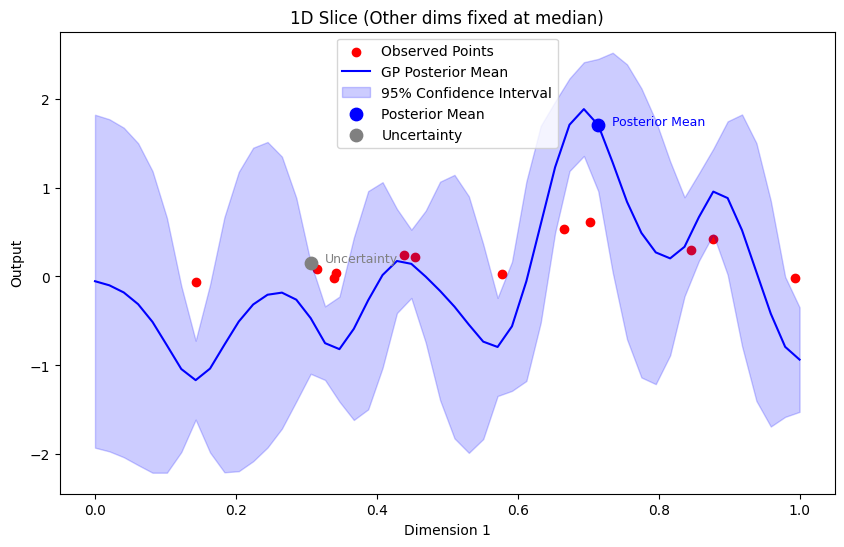

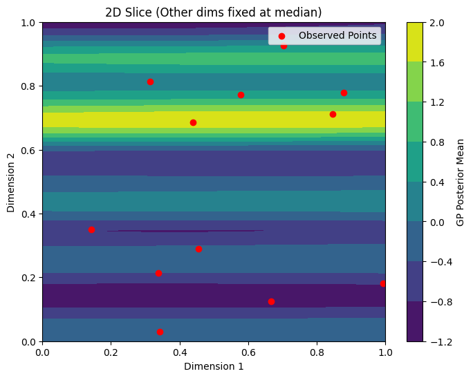

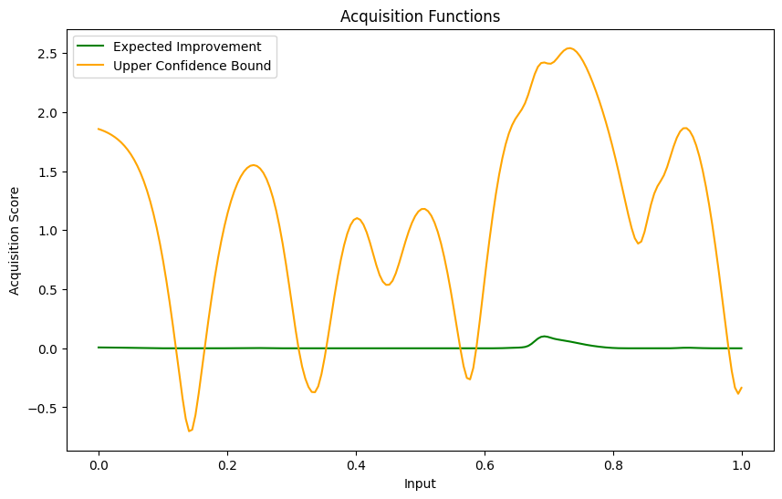

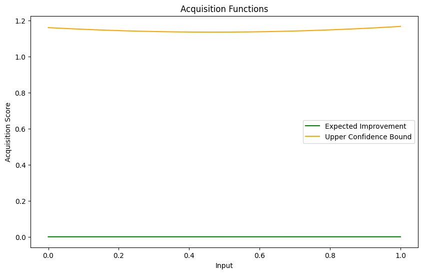

```python
print(X.ndim)
# Reshape X if needed (e.g., for 1D function)
if X.ndim == 1:
    X = X.reshape(-1, 1)

#print("Shape of X:", X.shape)
#print("Shape of Y:", Y.shape)

# Fit GP and compute acquisition scores
gp, _ = fit_gp(X, Y, random_state=0)

# Generate prediction grid based on dimensionality
#X_grid = np.linspace(0, 1, 100).reshape(-1, 1)
X_grid = np.random.uniform(0, 1, size =(1000,X.shape[1]))
#X_grid = np.linspace(0, 1, 200).reshape(-1, X.shape[1]) if X.shape[1] == 1 else np.random.uniform(0, 1, size=(500, X.shape[1]))

ei_scores = expected_improvement(X_grid, gp, Y_best=float(np.max(gp.y_train_)))
ucb_scores = upper_confidence_bound(X_grid, gp)

# Visualisations
#plot_gp_1d(X, Y, X_grid, gp)
#plot_acquisition_functions(X_grid, ei_scores, ucb_scores)
#plot_acquisition_functions(X_grid[:, 0], ei_scores, ucb_scores)


# Visualize slices of the surrogate model
# 1D slice for dimension 1
plot_gp_slice(X, Y, gp, dims_to_vary=[0])

# 2D slice for dimensions 1 and 2
plot_gp_slice(X, Y, gp, dims_to_vary=[0, 1])

# Visualize acquisition functions for dimension 1 slice
# For high dimensions, we show EI and UCB along the varied dimension
grid_dim1 = np.linspace(0, 1, 200)
X_full_dim1 = np.tile(np.median(X, axis=0), (200, 1))
X_full_dim1[:, 0] = grid_dim1
ei_dim1 = expected_improvement(X_full_dim1, gp, Y_best=float(np.max(gp.y_train_)))
ucb_dim1 = upper_confidence_bound(X_full_dim1, gp)
plot_acquisition_functions(grid_dim1, ei_dim1, ucb_dim1)


# Visualize acquisition functions for dimension 2 slice
grid_dim2 = np.linspace(0, 1, 200)
X_full_dim2 = np.tile(np.median(X, axis=0), (200, 1))
X_full_dim2[:, 1] = grid_dim2
ei_dim2 = expected_improvement(X_full_dim2, gp, Y_best=float(np.max(gp.y_train_)))
ucb_dim2 = upper_confidence_bound(X_full_dim2, gp)

plot_acquisition_functions(grid_dim2, ei_dim2, ucb_dim2)
```

### Notes for High-Dimensional Functions (e.g., Function 8 with 8D)

- Use `plot_gp_slice()` for selected dimensions (1D or 2D slices).
- For global patterns, use `plot_parallel_coordinates(X, Y)`.
- Acquisition functions can be visualized for individual dimensions by fixing others at median values.
- Consider dimensionality reduction (PCA or t-SNE) for exploratory visualization.

# Auto Plot Valid Slices

```python
def run_function_workflow(function_path, random_state=0):
    # 1) Load
    X = np.load(f'{function_path}/new_inputs.npy')
    Y = np.load(f'{function_path}/new_outputs.npy')
    if X.ndim == 1:
        X = X.reshape(-1, 1)

    print(f"[{function_path}] shapes – X: {X.shape}, Y: {Y.shape}")

    # 2) GP fit
    gp, _ = fit_gp(X, Y, random_state=random_state)

    # 3) Report current best
    idx_best = int(np.argmax(Y))
    X_best, Y_best = X[idx_best], float(Y[idx_best])
    print(f"[{function_path}] Current best Y: {Y_best:.6f} @ idx {idx_best}")
    print("X_best:", np.array2string(X_best, precision=6, separator=', '))

    # 4) Plots (dimension‑aware)
    D = X.shape[1]
    plot_gp_1d(X, Y, gp, dim=0)  # always show first dimension
    if D >= 2:
        plot_gp_1d(X, Y, gp, dim=1)
        # auto‑pick one 2D pair: the two dims with highest variance
        variances = np.var(X, axis=0)
        top2 = np.argsort(variances)[-2:]
        #plot_2d_ei_slice(X, Y, gp, d1=int(top2[0]), d2=int(top2[1]), n_points=80, Y_best=Y_best)
        Y_best_plot = float(np.max(gp.y_train_))   # training scale

    # 5) Precise next queries (top 5)
    numeric, formatted = propose_precise_next_queries(X, Y, gp, k_final=5, random_state=random_state)
    print(f"\n[{function_path}] Proposed next queries (top {len(formatted)} by EI):")
    for i, fq in enumerate(formatted, 1):
        print(f" {i}. {fq}")

    return gp, (numeric, formatted)
```

```
Numeric query: [0.69579601 0.07301803]
Formatted query: 0.695796-0.073018
```

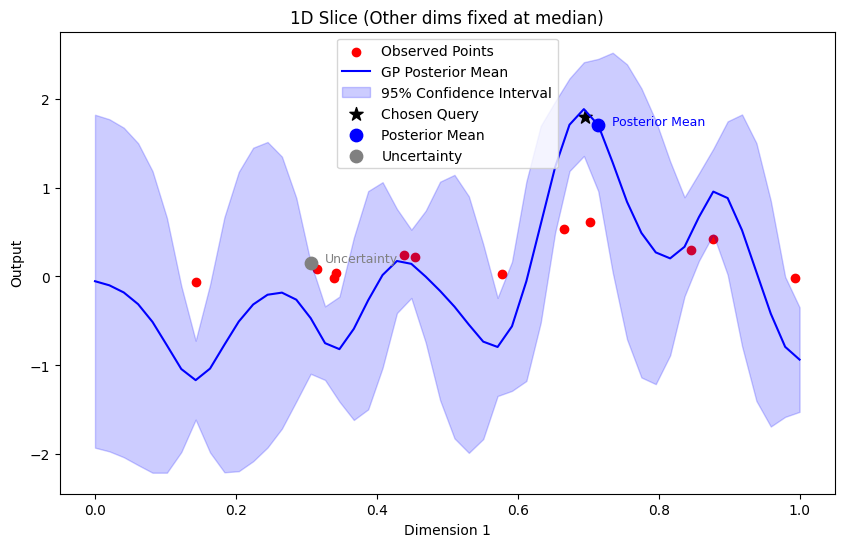

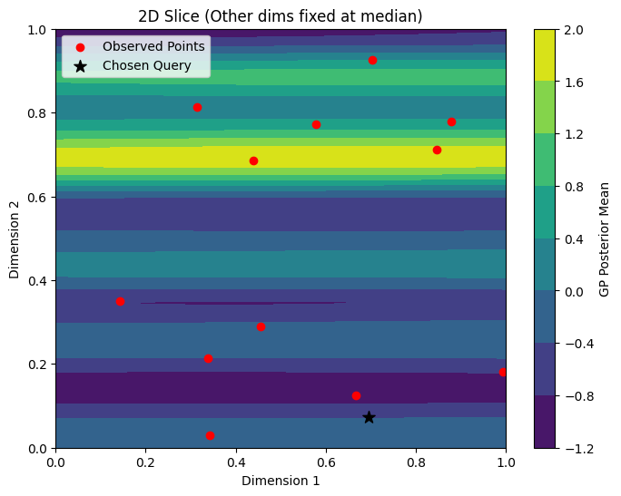

```python
# Example usage
numeric_query, formatted_query = generate_hybrid_query(function_path)
print("Numeric query:", numeric_query)
print("Formatted query:", formatted_query)

# Visualize chosen query on GP slice plots
plot_gp_slice(X, Y, gp, dims_to_vary=[0], query_point=numeric_query)
plot_gp_slice(X, Y, gp, dims_to_vary=[0, 1], query_point=numeric_query)
```

### Run Analysis

Fit the GP, plot slices, and print proposed queries.

```
[function_2] shapes – X: (12, 2), Y: (12,)
[function_2] Current best Y: 0.611205 @ idx 9
X_best: [0.702637, 0.926564]
```

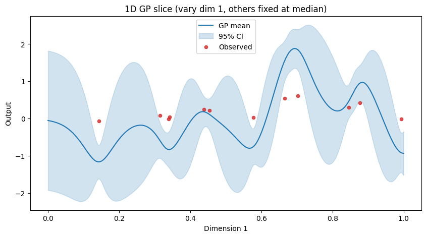

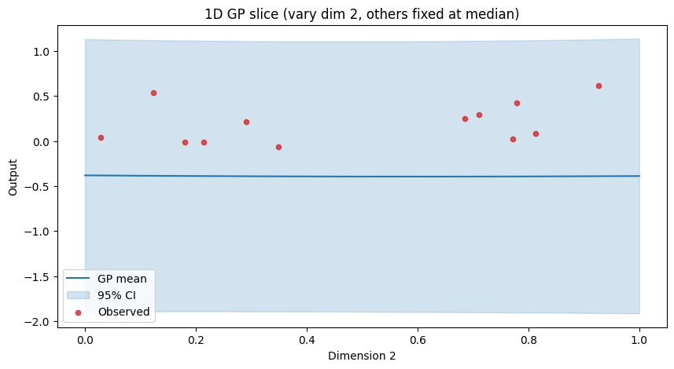

```
[function_2] Proposed next queries (top 5 by EI):
 1. 0.696647-0.127504
 2. 0.695547-0.046928
 3. 0.701270-0.046366
 4. 0.695820-0.112113
 5. 0.700324-0.119076

[Portal] function_2 top-1: 0.696647-0.127504
```

```python
# === SINGLE FUNCTION RUN (replaces legacy 'B. PER-FUNCTION WORKFLOW' cell) ===
# Choose the function you are updating this week (e.g., 'function_1')
#function_path = 'function_1'  # change to 'function_2', ..., 'function_8' as needed

# Execute the end-to-end workflow:
gp, (numeric_candidates, formatted_candidates) = run_function_workflow(function_path, random_state=0)

# The first formatted candidate is your portal-ready suggestion:
print(f"\n[Portal] {function_path} top-1: {formatted_candidates[0]}")
```